# Report for Practical Machine Learning Course Project

## Introduction

In this report, we will perform analysis on the Weight Lifting Exercise Dataset http://groupware.les.inf.puc-rio.br/har#weight_lifting_exercises. It collects body movement data from 6 participancts exercising in 5 different ways. The goal is to predict the way in which a particular exercise has been performed.

## Data Pre-processing

Firstly, let us read in the data and get a feeling of its structure. The reviewer may want to save and run this file in the same directory as the trainFile.

```r
library(caret)
trainFile = "pml-training.csv"
trainData = read.table(trainFile, header=TRUE, sep=",", row.names=1)

dim(trainData)
```

```
## [1] 19622   159
```

```r
summary(trainData)
```

```
##     user_name    raw_timestamp_part_1 raw_timestamp_part_2
##  adelmo  :3892   Min.   :1.322e+09    Min.   :   294
##  carlitos:3112   1st Qu.:1.323e+09    1st Qu.:252912
##  charles :3536   Median :1.323e+09    Median :496380
##  eurico  :3070   Mean   :1.323e+09    Mean   :500656
##  jeremy  :3402   3rd Qu.:1.323e+09    3rd Qu.:751891
##  pedro   :2610   Max.   :1.323e+09    Max.   :998801
##
##           cvtd_timestamp  new_window    num_window      roll_belt
##  28/11/2011 14:14: 1498   no :19216   Min.   :  1.0   Min.   :-28.90
##  05/12/2011 11:24: 1497   yes:  406   1st Qu.:222.0   1st Qu.:  1.10
##  30/11/2011 17:11: 1440               Median :424.0   Median :113.00
##  05/12/2011 11:25: 1425               Mean   :430.6   Mean   : 64.41
##  02/12/2011 14:57: 1380               3rd Qu.:644.0   3rd Qu.:123.00
##  02/12/2011 13:34: 1375               Max.   :864.0   Max.   :162.00
##  (Other)         :11007
##    pitch_belt          yaw_belt       total_accel_belt kurtosis_roll_belt
##  Min.   :-55.8000   Min.   :-180.00   Min.   : 0.00             :19216
##  1st Qu.:  1.7600   1st Qu.: -88.30   1st Qu.: 3.00    #DIV/0!  :   10
##  Median :  5.2800   Median : -13.00   Median :17.00    -1.908453:    2
##  Mean   :  0.3053   Mean   : -11.21   Mean   :11.31    -0.016850:    1
##  3rd Qu.: 14.9000   3rd Qu.:  12.90   3rd Qu.:18.00    -0.021024:    1
##  Max.   : 60.3000   Max.   : 179.00   Max.   :29.00    -0.025513:    1
##                                                        (Other)  :  391
##  kurtosis_picth_belt kurtosis_yaw_belt skewness_roll_belt
##           :19216            :19216              :19216
##  #DIV/0!  :   32     #DIV/0!:  406     #DIV/0!  :    9
##  47.000000:    4                       0.000000 :    4
##  -0.150950:    3                       0.422463 :    2
##  -0.684748:    3                       -0.003095:    1
##  -1.750749:    3                       -0.010002:    1
##  (Other)  :  361                       (Other)  :  389
##  skewness_roll_belt.1 skewness_yaw_belt max_roll_belt     max_picth_belt
##           :19216             :19216     Min.   :-94.300   Min.   : 3.00
##  #DIV/0!  :   32      #DIV/0!:  406     1st Qu.:-88.000   1st Qu.: 5.00
##  0.000000 :    4                        Median : -5.100   Median :18.00
##  -2.156553:    3                        Mean   : -6.667   Mean   :12.92
##  -3.072669:    3                        3rd Qu.: 18.500   3rd Qu.:19.00
##  -6.324555:    3                        Max.   :180.000   Max.   :30.00
##  (Other)  :  361                        NA's   :19216     NA's   :19216
```

[output cut: 313 more lines]

```
##  Min.   :-446.00   Min.   :-1280.0   Min.   :-896.0   Min.   :-973.0
##  1st Qu.:-182.00   1st Qu.: -616.0   1st Qu.:   2.0   1st Qu.: 191.0
##  Median : -39.00   Median : -378.0   Median : 591.0   Median : 511.0
##  Mean   : -55.29   Mean   : -312.6   Mean   : 380.1   Mean   : 393.6
##  3rd Qu.:  26.00   3rd Qu.:  -73.0   3rd Qu.: 737.0   3rd Qu.: 653.0
##  Max.   : 291.00   Max.   :  672.0   Max.   :1480.0   Max.   :1090.0
##
##  classe
##  A:5580
##  B:3797
##  C:3422
##  D:3216
##  E:3607
##
##
```

The initial analysis tells us some information:

- The training set contains 19622 samples, with 158 original features;
- The columns related to timestamp or time window are of less use to our prediction;
- Many features have up to 19216 empty entries or NA’s, or even some strange notation “#DIV/0!”.

Therefore, we clean the dataset by removing unnecessary information or the ones conveying less useful information, e.g., the values are almost the same, or large amount of the values are NA’s.

```r
trainData = trainData[,c(-2:-6)]  # remove timestamp or time window columns

nzvIndex = nearZeroVar(trainData)
colnames(trainData)[nzvIndex]
```

```
##  [1] "kurtosis_roll_belt"      "kurtosis_picth_belt"
##  [3] "kurtosis_yaw_belt"       "skewness_roll_belt"
##  [5] "skewness_roll_belt.1"    "skewness_yaw_belt"
##  [7] "max_yaw_belt"            "min_yaw_belt"
##  [9] "amplitude_yaw_belt"      "avg_roll_arm"
## [11] "stddev_roll_arm"         "var_roll_arm"
## [13] "avg_pitch_arm"           "stddev_pitch_arm"
## [15] "var_pitch_arm"           "avg_yaw_arm"
## [17] "stddev_yaw_arm"          "var_yaw_arm"
## [19] "kurtosis_roll_arm"       "kurtosis_picth_arm"
## [21] "kurtosis_yaw_arm"        "skewness_roll_arm"
## [23] "skewness_pitch_arm"      "skewness_yaw_arm"
## [25] "max_roll_arm"            "min_roll_arm"
## [27] "min_pitch_arm"           "amplitude_roll_arm"
## [29] "amplitude_pitch_arm"     "kurtosis_roll_dumbbell"
## [31] "kurtosis_picth_dumbbell" "kurtosis_yaw_dumbbell"
## [33] "skewness_roll_dumbbell"  "skewness_pitch_dumbbell"
## [35] "skewness_yaw_dumbbell"   "max_yaw_dumbbell"
## [37] "min_yaw_dumbbell"        "amplitude_yaw_dumbbell"
## [39] "kurtosis_roll_forearm"   "kurtosis_picth_forearm"
## [41] "kurtosis_yaw_forearm"    "skewness_roll_forearm"
## [43] "skewness_pitch_forearm"  "skewness_yaw_forearm"
## [45] "max_roll_forearm"        "max_yaw_forearm"
## [47] "min_roll_forearm"        "min_yaw_forearm"
## [49] "amplitude_roll_forearm"  "amplitude_yaw_forearm"
## [51] "avg_roll_forearm"        "stddev_roll_forearm"
## [53] "var_roll_forearm"        "avg_pitch_forearm"
## [55] "stddev_pitch_forearm"    "var_pitch_forearm"
## [57] "avg_yaw_forearm"         "stddev_yaw_forearm"
## [59] "var_yaw_forearm"
```

```r
trainData = trainData[,-nzvIndex] # remove the columns giving less information

nrow = dim(trainData)[1]
ncol = dim(trainData)[2]
naIndex = integer()
for (i in 1:ncol) {
  if (sum(is.na(trainData[,i])) > 0.5*nrow) {
    naIndex = c(naIndex, i)
  }
}
colnames(trainData)[naIndex]
```

```
##  [1] "max_roll_belt"            "max_picth_belt"
##  [3] "min_roll_belt"            "min_pitch_belt"
##  [5] "amplitude_roll_belt"      "amplitude_pitch_belt"
##  [7] "var_total_accel_belt"     "avg_roll_belt"
##  [9] "stddev_roll_belt"         "var_roll_belt"
## [11] "avg_pitch_belt"           "stddev_pitch_belt"
## [13] "var_pitch_belt"           "avg_yaw_belt"
## [15] "stddev_yaw_belt"          "var_yaw_belt"
## [17] "var_accel_arm"            "max_picth_arm"
## [19] "max_yaw_arm"              "min_yaw_arm"
## [21] "amplitude_yaw_arm"        "max_roll_dumbbell"
## [23] "max_picth_dumbbell"       "min_roll_dumbbell"
## [25] "min_pitch_dumbbell"       "amplitude_roll_dumbbell"
## [27] "amplitude_pitch_dumbbell" "var_accel_dumbbell"
## [29] "avg_roll_dumbbell"        "stddev_roll_dumbbell"
## [31] "var_roll_dumbbell"        "avg_pitch_dumbbell"
## [33] "stddev_pitch_dumbbell"    "var_pitch_dumbbell"
## [35] "avg_yaw_dumbbell"         "stddev_yaw_dumbbell"
## [37] "var_yaw_dumbbell"         "max_picth_forearm"
## [39] "min_pitch_forearm"        "amplitude_pitch_forearm"
## [41] "var_accel_forearm"
```

```r
trainData = trainData[,-naIndex] # remove the columns having more than half NA's

dim(trainData)
```

```
## [1] 19622    54
```

Now the dataset becomes much more concise. We continue by analyzing the correlations among different features. The visualization of feature correlations are plotted below.

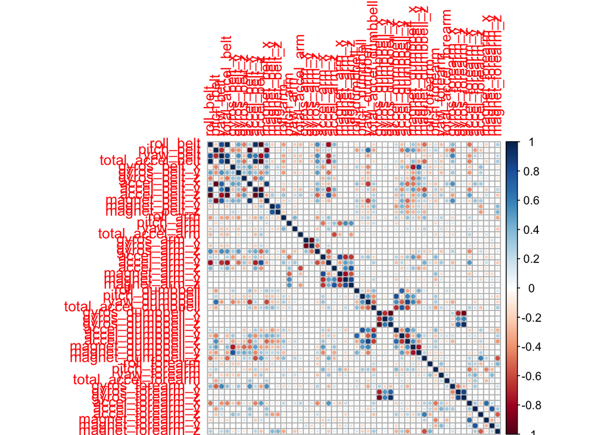

```r
library(corrplot)
temp = trainData[,c(-1,-dim(trainData)[2])] # remove non-numeric columns
corMat = cor(temp)
corrplot(corMat)
```

Notably, a few features are high correlated with absolute correlation coefficient larger than 0.7. We shall remove these highly correlated features.

```r
corMat = corMat - diag(diag(corMat))
corMat = abs(corMat)
# corrplot(corMat)
corIndex = findCorrelation(corMat, cutoff=0.7)
colnames(temp)[corIndex]
```

```
##  [1] "accel_belt_z"      "roll_belt"         "accel_belt_y"
##  [4] "accel_arm_y"       "total_accel_belt"  "yaw_belt"
##  [7] "accel_dumbbell_z"  "accel_belt_x"      "pitch_belt"
## [10] "magnet_dumbbell_x" "accel_dumbbell_y"  "magnet_dumbbell_y"
## [13] "accel_arm_x"       "accel_dumbbell_x"  "accel_arm_z"
## [16] "magnet_arm_y"      "magnet_belt_y"     "accel_forearm_y"
## [19] "gyros_arm_y"       "gyros_forearm_z"   "gyros_forearm_y"
## [22] "gyros_dumbbell_x"
```

```r
temp = temp[,-corIndex]
trainData = data.frame(trainData[,1], temp, trainData[,dim(trainData)[2]])
colnames(trainData)[1] = "user_name"
colnames(trainData)[dim(trainData)[2]] = "classe"
```

Finally we create dummy variables from the column “user_name”.

```r
trainData = data.frame(model.matrix(classe~.-1, data=trainData), trainData$classe)
colnames(trainData)[dim(trainData)[2]] = "classe"
# head(trainData)
dim(trainData)
```

```
## [1] 19622    37
```

Now the dataset becomes much thinner with only 36 features.

## Model Training

Even though we have tried quite a few machine learning models, here we only show the final model using Random Forest method due to space limit. Our results show that Random Forest (“rf”) and SVM with Polynomial Kernel both perform very well.

When training the model, we define the pre-processing method as c(“center”, “scale”) so as to normalize the features. We also define cross-validation in the training control function to prevent overfitting on the training set. Actually this setting will partition the training set into training and cross-validation set.

```r
modFitRf = train(classe~., method="rf", preProcess=c("center", "scale"), trControl=trainControl(method="cv"), data=trainData)
predTrainRf = predict(modFitRf, trainData[,-dim(trainData)[2]])
confusionMatrix(predTrainRf, trainData$classe)
```

```
## Confusion Matrix and Statistics
##
##           Reference
## Prediction    A    B    C    D    E
##          A 5580    0    0    0    0
##          B    0 3797    0    0    0
##          C    0    0 3422    0    0
##          D    0    0    0 3216    0
##          E    0    0    0    0 3607
##
## Overall Statistics
##
##                Accuracy : 1
##                  95% CI : (0.9998, 1)
##     No Information Rate : 0.2844
##     P-Value [Acc > NIR] : < 2.2e-16
##
##                   Kappa : 1
##  Mcnemar's Test P-Value : NA
##
## Statistics by Class:
##
##                      Class: A Class: B Class: C Class: D Class: E
## Sensitivity            1.0000   1.0000   1.0000   1.0000   1.0000
## Specificity            1.0000   1.0000   1.0000   1.0000   1.0000
## Pos Pred Value         1.0000   1.0000   1.0000   1.0000   1.0000
## Neg Pred Value         1.0000   1.0000   1.0000   1.0000   1.0000
## Prevalence             0.2844   0.1935   0.1744   0.1639   0.1838
## Detection Rate         0.2844   0.1935   0.1744   0.1639   0.1838
## Detection Prevalence   0.2844   0.1935   0.1744   0.1639   0.1838
## Balanced Accuracy      1.0000   1.0000   1.0000   1.0000   1.0000
```

This model performs very well on the training dataset, just perfectly predicts the results. As we tested but not showed here, SVM with Polynomial Kernel also results very high accuracy. But for models like CART, Naive Bayes, Stochastic Gradient Boosting, and SVM with Linear Kernel. the training performances are not very satisfactory with only 50% to 70% accuracy. So in the following we will use Random Forest for prediction.

## Testing

To perform testing on the test dataset, we first clean the dataset as what we did on the training set. In particular, we follow the procedure that remove the timestamp columns, remove the near-zero-variance columns, remove the columns have too many NA’s, as well as the columns with high correlation.

```r
testFile = "pml-testing.csv"
testData = read.table(testFile, header=TRUE, sep=",", row.names=1)
# pre-processing testData following to same procedure for the trainData
testData = testData[,c(-2:-6)]
testData = testData[,-nzvIndex]
testData = testData[,-naIndex]
temp = testData[,c(-1,-dim(testData)[2])]
temp = temp[,-corIndex]
testData = data.frame(testData[,1], temp, testData[,dim(testData)[2]])
colnames(testData)[1] = "user_name"
colnames(testData)[dim(testData)[2]] = "problem_id"
testData = data.frame(model.matrix(problem_id~.-1, data=testData), testData$problem_id)
colnames(testData)[dim(testData)[2]] = "problem_id"
```

Then we perform prediction on the cleaned dataset using Random Forest model as trained just now. The results are as follows.

```r
predRf = predict(modFitRf, testData)
predRf
```

```
##  [1] B A B A A E D B A A B C B A E E A B B B
## Levels: A B C D E
```

This results are the same as the results given by SVM with Polynomial Kernel, and more or less different from the results given by CART, Naive Bayes, Stochastic Gradient Boosting, and SVM with Linear Kernel.

## Conclusion

In this report we illustrate the process of preprocessing the training data, training the clean dataset using different models with cross validation incorporated, as well as predicting on testing file. We note that both Random Forest and SVM with Polynomial Kernel give very accurate predictions, but the former is much faster than the latter.